# FishEggs Test

Last Updated: October 22, 2024 08:24:23

### Write down an equation for the least squares line and comment on what it appears to indicate about the relationship between PctDM and Age.

```r
model <- lm(PctDM ~ Age, data = fishEggs)
summary(model)
```

```
##
## Call:
## lm(formula = PctDM ~ Age, data = fishEggs)
##
## Residuals:
##     Min      1Q  Median      3Q     Max
## -2.9091 -0.8471  0.3822  1.0271  2.1409
##
## Coefficients:
##             Estimate Std. Error t value Pr(>|t|)
## (Intercept) 38.70206    0.86783  44.596   <2e-16 ***
## Age         -0.21033    0.07313  -2.876    0.007 **
## ---
## Signif. codes:  0 '***' 0.001 '**' 0.01 '*' 0.05 '.' 0.1 ' ' 1
##
## Residual standard error: 1.426 on 33 degrees of freedom
## Multiple R-squared:  0.2004, Adjusted R-squared:  0.1762
## F-statistic: 8.272 on 1 and 33 DF,  p-value: 0.007001
```

`PctDM = 38.70206 - 0.21033 * Age` The equation indicates that the percentage of dry matter in fish eggs decreases by 0.21033 for each additional year of age, and that it starts at 38.70206 when the age is 0.

### What percentage of the variability in PctDM does Age explain for these fish?

```r
summary(model)$r.squared
```

```
## [1] 0.2004315
```

20.04% of the variation in in PctDM is accounted for by the least squared regression line of Age.

### Is there evidence that the relationship in (#1) is statistically significant? Explain how you know that it is or is not.

```r
summary(model)$coefficients
```

```
##               Estimate Std. Error   t value     Pr(>|t|)
## (Intercept) 38.7020617 0.86783471 44.596121 4.503099e-31
## Age         -0.2103312 0.07312934 -2.876154 7.001273e-03
```

Since the p-value for the Age coefficient is less than 0.05, we can reject the null hypothesis that the coefficient is equal to 0. Therefore, there is evidence that the relationship between PctDM and Age is statistically significant.

### Produce a plot of the residuals versus the fits for the simple linear model. Does there appear to be any regular pattern?

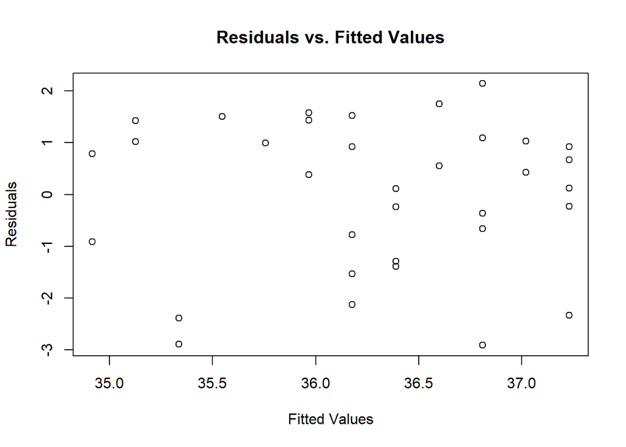

```r
plot(model$fitted.values, model$residuals, xlab = "Fitted Values", ylab = "Residuals", main = "Residuals vs. Fitted Values")
```

The points on the graph appear to be spread out and do not follow a linear pattern.

### Modify your plot in (#4) to show the points for each Month (Sept/Nov) with different symbols or colors. What (if anything) do you observe about how the residuals might be related to the month?

[figure not shown]

```r
plot(model$fitted.values, model$residuals, xlab = "Fitted Values", ylab = "Residuals", main = "Residuals vs. Fitted Values", pch = ifelse(Month == "Sep", 1, 2))
legend("topright", legend = c("Nov", "Sep"), pch = c(1, 2))
```

### Now fit a multiple regression model, using an indicator (Sept) for the month and interaction product, to compare the regression lines for September and November.

```r
model2 <- lm(PctDM ~ Age + Sept + Age:Sept, data = fishEggs)
summary(model2)
```

```
##
## Call:
## lm(formula = PctDM ~ Age + Sept + Age:Sept, data = fishEggs)
##
## Residuals:
##     Min      1Q  Median      3Q     Max
## -2.9559 -0.5576  0.2305  0.7522  2.5029
##
## Coefficients:
##             Estimate Std. Error t value Pr(>|t|)
## (Intercept) 39.39733    1.07376  36.691   <2e-16 ***
## Age         -0.21821    0.08942  -2.440   0.0206 *
## Sept        -1.27623    1.51190  -0.844   0.4051
## Age:Sept    -0.02144    0.12782  -0.168   0.8679
## ---
## Signif. codes:  0 '***' 0.001 '**' 0.01 '*' 0.05 '.' 0.1 ' ' 1
##
## Residual standard error: 1.242 on 31 degrees of freedom
## Multiple R-squared:  0.4303, Adjusted R-squared:  0.3752
## F-statistic: 7.806 on 3 and 31 DF,  p-value: 0.000505
```

### Do you need both terms for a difference in intercepts and slopes? If not, delete any terms that aren’t needed and run the new model.

```r
model3 <- lm(PctDM ~ Age + Sept, data = fishEggs)
summary(model3)
```

```
##
## Call:
## lm(formula = PctDM ~ Age + Sept, data = fishEggs)
##
## Residuals:
##     Min      1Q  Median      3Q     Max
## -2.9100 -0.5869  0.2974  0.7599  2.4380
##
## Coefficients:
##             Estimate Std. Error t value Pr(>|t|)
## (Intercept) 39.51922    0.77827  50.778  < 2e-16 ***
## Age         -0.22870    0.06292  -3.635 0.000965 ***
## Sept        -1.51929    0.42342  -3.588 0.001096 **
## ---
## Signif. codes:  0 '***' 0.001 '**' 0.01 '*' 0.05 '.' 0.1 ' ' 1
##
## Residual standard error: 1.223 on 32 degrees of freedom
## Multiple R-squared:  0.4298, Adjusted R-squared:  0.3942
## F-statistic: 12.06 on 2 and 32 DF,  p-value: 0.0001248
```

### What percentage of the variability in PctDM does the model in (#6) explain for these fish?

```r
summary(model3)$r.squared
```

```
## [1] 0.4298313
```

### Redo the plot in (#5) showing the residuals versus fits for the model in (#6) with different symbols for the months. Does this plot show an improvement over your plot in (#5)? Explain why.

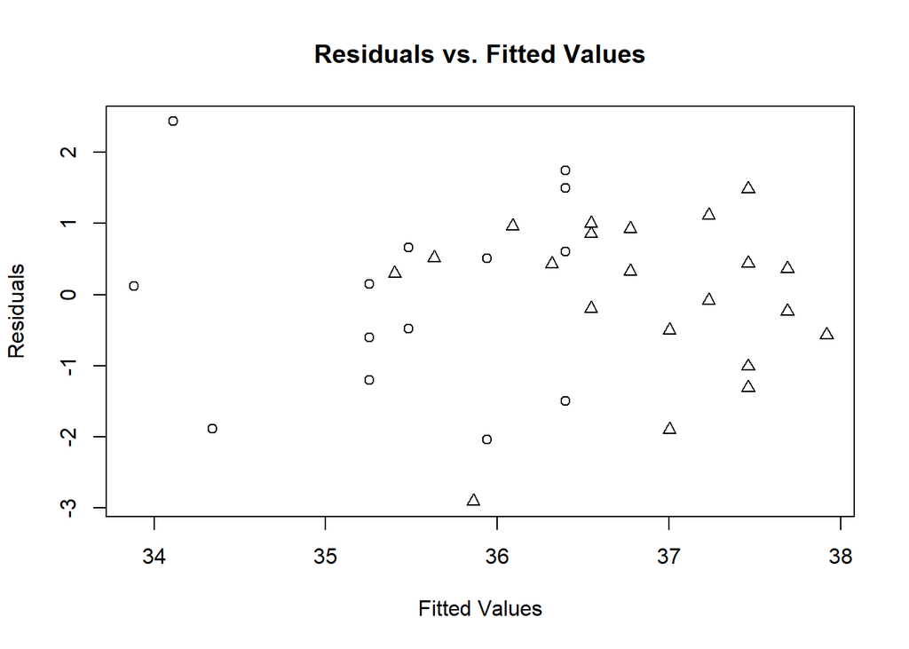

```r
plot(model3$fitted.values, model3$residuals, xlab = "Fitted Values", ylab = "Residuals", main = "Residuals vs. Fitted Values", pch = ifelse(Month == "Sep", 1, 2))
```